# More on GGplot2 Customization

### Question 4

Consider the following code:

```r
ggplot(data = colleges,
       mapping = aes(x = Cost, y = Net_Tuition, color = Type)) +
  geom_point() +
  scale_color_viridis_c()
```

**A.** Run the code. Read the error message and explain why `scale_color_viridis_c()` cannot be used here.

**B.** Modify the scale function so that the graph works correctly.

**C.** The ColorBrewer palettes we encountered earlier can also be used with discrete or continuous variables. Investigate the difference between `scale_color_brewer()` and `scale_color_distiller()`. Which function would be appropriate for Type? Recreate the graph using that function and a `ColorBrewer` palette of your choice.

## Color versus Fill

The `color` aesthetic is not synonymous with every color that appears on a graph.

In `ggplot2`, `color` generally controls the color of points and lines or the **outline** of a shape, while `fill` controls the color of its **interior**.

For example:

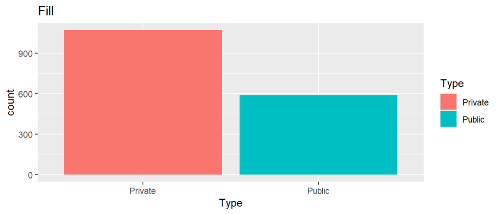

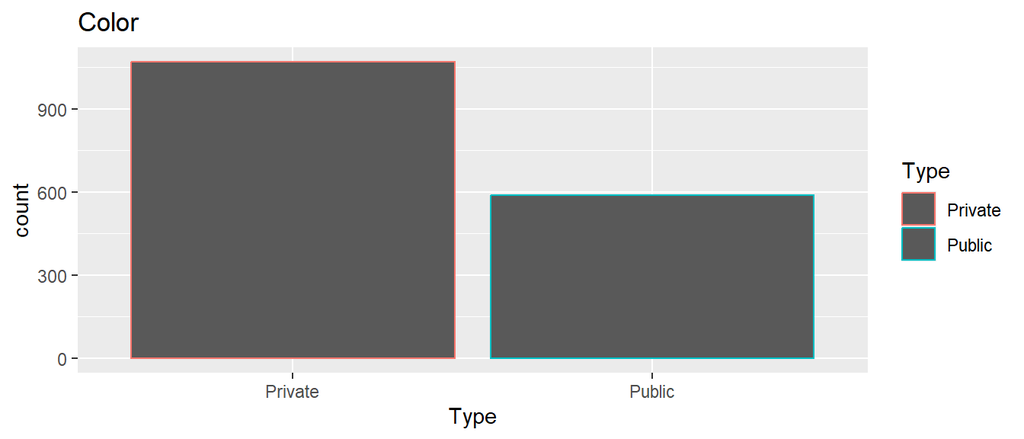

```r
ggplot(data = colleges,
       mapping = aes(x = Type, fill = Type)) +
  geom_bar() +
  labs(title = "Fill")

ggplot(data = colleges,
       mapping = aes(x = Type, color = Type)) +
  geom_bar() +
  labs(title = "Color")
```

Because `color` and `fill` are different aesthetics, they also have different scale functions.

For example:

```r
scale_color_brewer()
scale_fill_brewer()

scale_color_viridis_c()
scale_fill_viridis_c()

scale_color_manual()
scale_fill_manual()
```

The scale function needs to correspond to the aesthetic that was actually mapped.

For example:

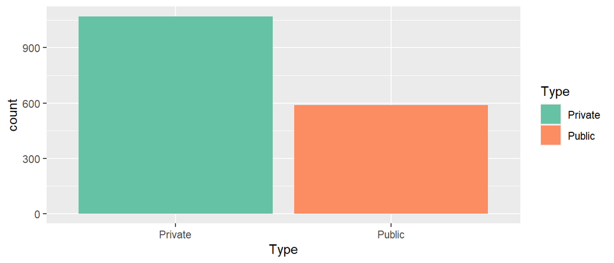

```r
ggplot(data = colleges,
       mapping = aes(x = Type, fill = Type)) +
  geom_bar() +
  scale_fill_brewer(palette = "Set2")
```

Here `Type` is mapped to `fill`, so we use `scale_fill_brewer()` rather than `scale_color_brewer()`.

## Position Scales

Scales are not limited to color. The x- and y-axes of a graph are also controlled by scales.

For example:

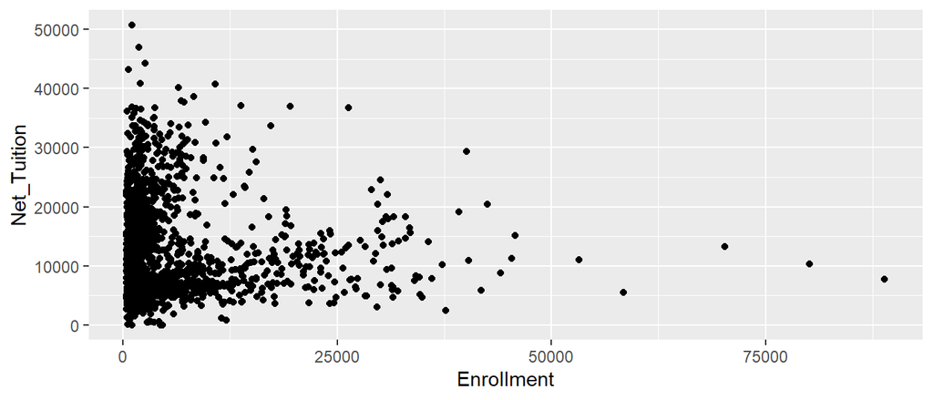

```r
ggplot(data = colleges,
       mapping = aes(x = Enrollment, y = Net_Tuition)) +
  geom_point()
```

Since `Enrollment` is quantitative, its x-axis is controlled by a continuous position scale. We can explicitly modify this scale using:

```r
scale_x_continuous()
```

Similarly, a continuous variable on the y-axis can be modified using:

```r
scale_y_continuous()
```

One useful application is changing the transformation used to display an axis.

For example, college enrollment is highly skewed because a relatively small number of institutions have extremely large enrollments:

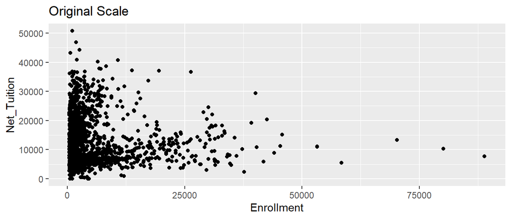

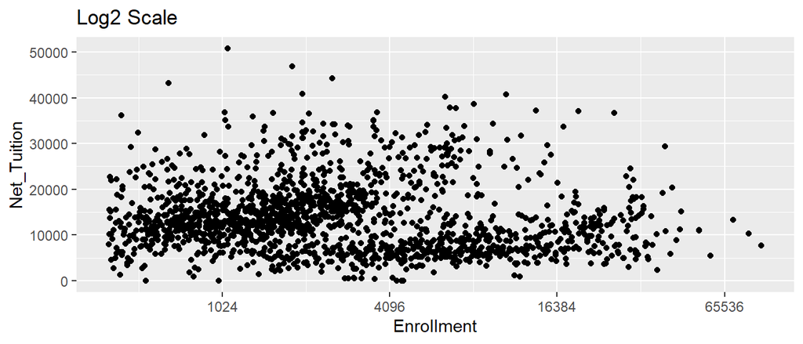

```r
ggplot(data = colleges,
       mapping = aes(x = Enrollment, y = Net_Tuition)) +
  geom_point() +
  labs(title = "Original Scale")

ggplot(data = colleges,
       mapping = aes(x = Enrollment, y = Net_Tuition)) +
  geom_point() +
  scale_x_continuous(transform = "log2") +
  labs(title = "Log2 Scale")
```

Both graphs contain the same observations. The second graph changes the **scale used to display their positions** on the x-axis.

Other transformations are available. For example:

```r
scale_x_continuous(transform = "log10")
scale_x_continuous(transform = "sqrt")
scale_x_continuous(transform = "reverse")
```

Similar transformations can be applied to the y-axis using `scale_y_continuous()`.

A transformation changes how values are positioned along an axis; it does not remove or alter the original observations in the data.

### Question 5

Transforming a scale is not only useful for changing the appearance of a graph. Sometimes a transformation can reveal a relationship between variables that is difficult to see on their original scales. This can be particularly useful when we are interested in fitting a linear relationship between variables.

Consider the following graph:

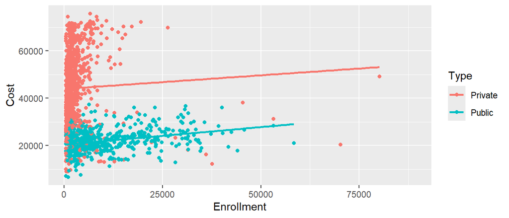

```r
ggplot(data = colleges,
       mapping = aes(x = Enrollment, y = Cost, color = Type)) +
  geom_point() +
  geom_smooth(method = "lm", se = FALSE)
```

The lines show the fitted linear relationship between `Enrollment` and `Cost` separately for public and private colleges.

**A.** Examine the graph and the two fitted lines. Does a linear relationship appear to describe the relationship between `Enrollment` and `Cost` particularly well on the original scale? Explain briefly.

**B.** Modify the x-axis using

```r
scale_x_continuous(transform = "log2")
```

How does transforming `Enrollment` change the appearance of the relationship?

**C.** Based on the transformed graph, does either college type seem to have a roughly linear relationship with `log2(Enrollment)`? Describe what you see.

# Guides and Legends

When an aesthetic represents a variable, the reader needs some way to determine what the different colors, shapes, or other visual properties mean. These references are called **guides**.

Guides are closely connected to the aesthetic mappings and scales we have already discussed. The mapping in `aes()` determines **which variable** controls an aesthetic, the scale determines **how the values are displayed**, and the guide explains that scale to the reader.

For categorical color mappings, the guide will usually appear as a legend:

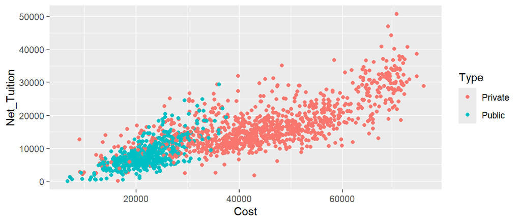

```r
ggplot(data = colleges,
       mapping = aes(x = Cost, y = Net_Tuition, color = Type)) +
  geom_point()
```

For continuous color mappings, the guide commonly appears as a color bar:

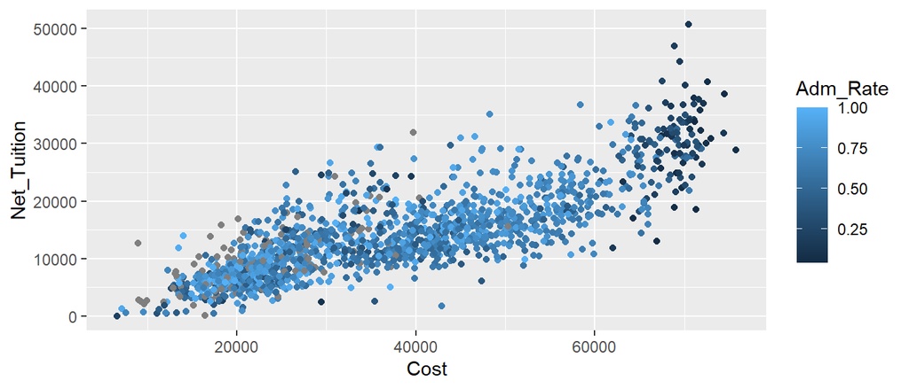

```r
ggplot(data = colleges,
       mapping = aes(x = Cost, y = Net_Tuition, color = Adm_Rate)) +
  geom_point()
```

## Modifying Guides

When modifying a guide, we generally refer to it using the **name of the aesthetic that created it**. In other words, look back at the argument used inside `aes()`.

For example, if we map

```r
aes(color = Adm_Rate)
```

then the corresponding guide is associated with `color`. We can change its title using:

```r
labs(color = "Admissions Rate")
```

Similarly, a guide created by `fill = Type` would be modified using `fill`, while a guide created by `shape = Type` would be modified using `shape`.

For example:

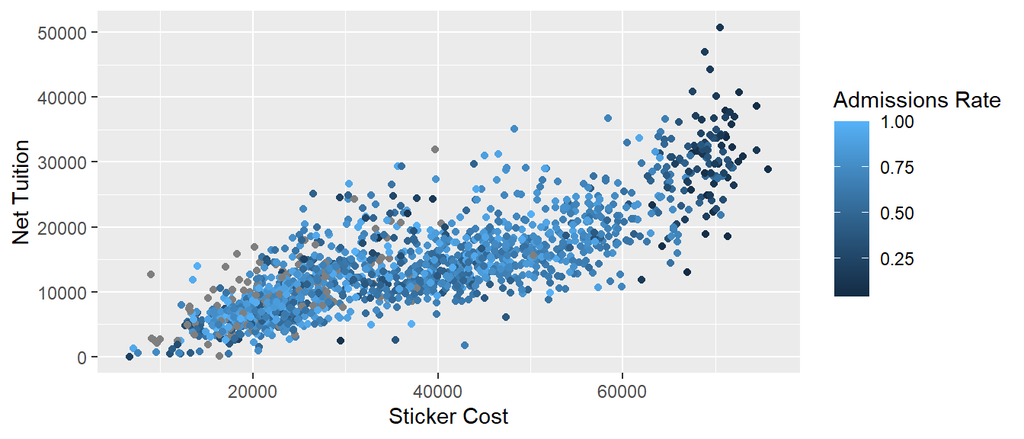

```r
ggplot(data = colleges,
       mapping = aes(x = Cost, y = Net_Tuition, color = Adm_Rate)) +
  geom_point() +
  labs(
    x = "Sticker Cost",
    y = "Net Tuition",
    color = "Admissions Rate"
  )
```

Notice that we use `color = "Admissions Rate"` rather than `Adm_Rate = "Admissions Rate"`. Here, `color` refers to the **aesthetic**, while `"Admissions Rate"` is the new title we want displayed for its guide.

## Multiple Guides

A graph can have multiple guides when multiple aesthetics are mapped to variables. For example:

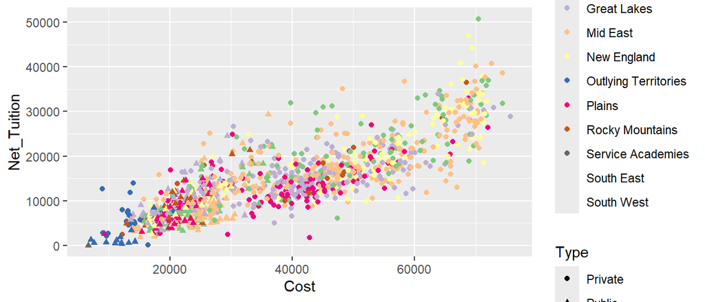

```r
ggplot(data = colleges,
       mapping = aes(x = Cost, y = Net_Tuition,
                     color = Region, shape = Type)) +
  geom_point() + scale_color_brewer(palette="Accent")
```

Here, `color` represents `Region` while `shape` represents `Type`. `ggplot2` therefore provides a guide explaining each mapping.

Each guide can be modified using the corresponding aesthetic name:

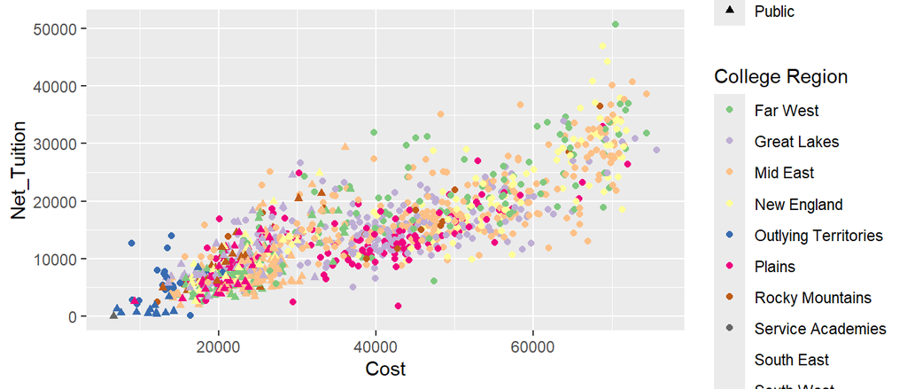

```r
ggplot(data = colleges,
       mapping = aes(x = Cost, y = Net_Tuition,
                     color = Region, shape = Type)) +
  geom_point() + scale_color_brewer(palette="Accent") +
  labs(
    color = "College Region",
    shape = "College Type"
  )
```

This produces two separate guides, and with many categories they can take up quite a bit of space. There are additional options for controlling the size and arrangement of guides, but we will not worry about those details here. The reality is that we should probably find a different way to visualize this many categories.

## Moving and Removing Guides

As we saw earlier, the position of the guides can be changed using `theme()`:

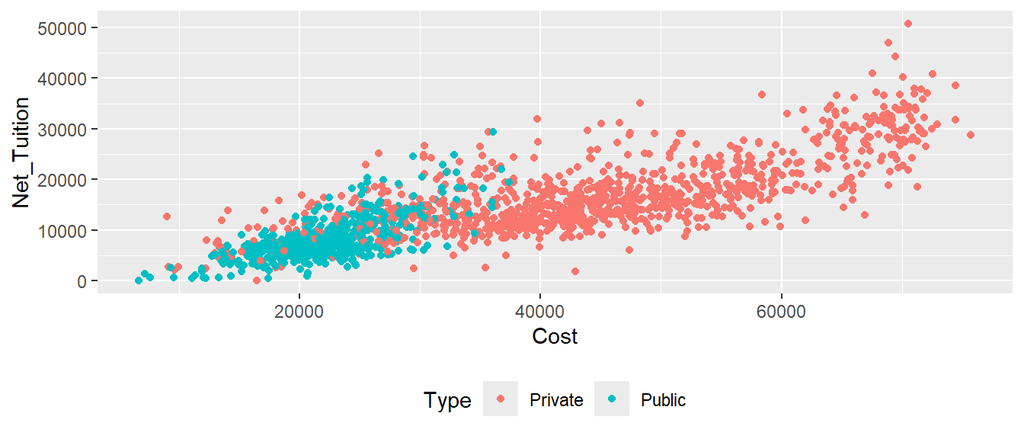

```r
ggplot(data = colleges,
       mapping = aes(x = Cost, y = Net_Tuition, color = Type)) +
  geom_point() +
  theme(legend.position = "bottom")
```

Guides can also be removed when they are not needed:

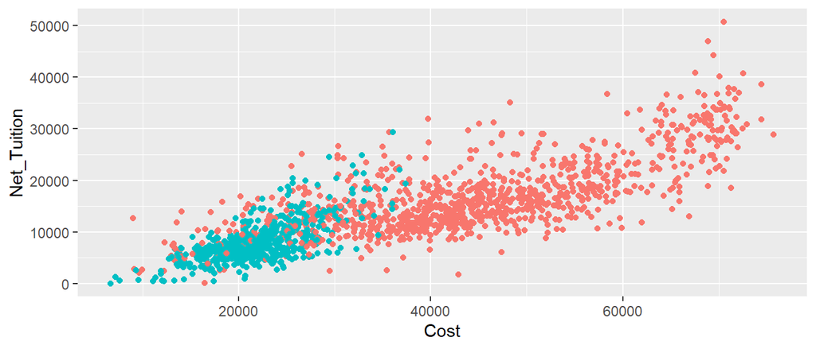

```r
ggplot(data = colleges,
       mapping = aes(x = Cost, y = Net_Tuition, color = Type)) +
  geom_point() +
  theme(legend.position = "none")
```

Removing a guide does **not** remove the aesthetic mapping. It only removes the reference that explains the mapping to the reader.

# More Control over Individual Layers

In the previous lab, we saw that data and aesthetic mappings placed in `ggplot()` are inherited by subsequent layers:

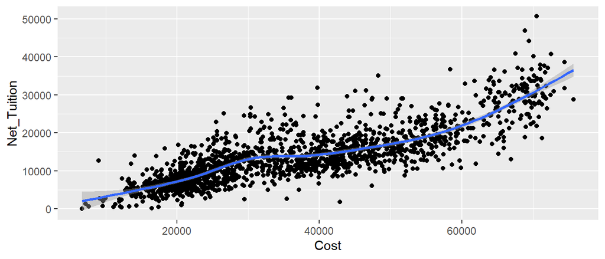

```r
ggplot(data = colleges,
       mapping = aes(x = Cost, y = Net_Tuition)) +
  geom_point() +
  geom_smooth()
```

However, individual layers can supply their own **data**, **aesthetic mappings**, and **appearance options**.

For example, we can display every college in the background but add a second layer containing only Iowa colleges:

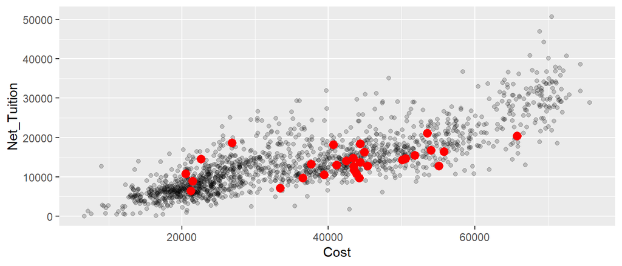

```r
ggplot(data = colleges,
       mapping = aes(x = Cost, y = Net_Tuition)) +
  geom_point(alpha = 0.2) +
  geom_point(
    data = subset(colleges, State == "IA"),
    color = "red",
    size = 3
  )
```

Both layers inherit `x = Cost` and `y = Net_Tuition` from `ggplot()`. However, the second layer replaces the inherited data with the subset of Iowa colleges.

The second layer could also add its own aesthetic mapping:

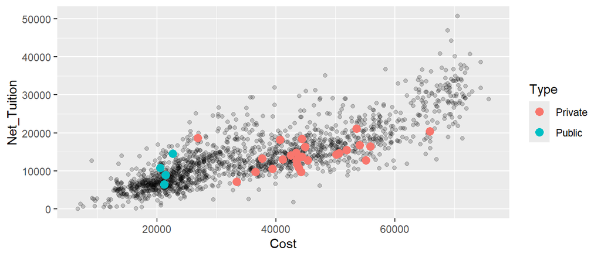

```r
ggplot(data = colleges,
       mapping = aes(x = Cost, y = Net_Tuition)) +
  geom_point(alpha = 0.2) +
  geom_point(
    data = subset(colleges, State == "IA"),
    mapping = aes(color = Type),
    size = 3
  )
```

Now only the Iowa colleges are colored according to `Type`.

Notice that the individual layer has three things we can control separately:

- `data` — which observations are displayed by the layer
- `mapping` — which variables control visual properties
- other arguments — fixed properties such as `size`, `alpha`, or a particular color

The order of the layers also matters. Layers added later are drawn over layers added earlier. This is why the highlighted Iowa colleges appear on top of the faint background points.

### Question 6

Modify the previous graph as follows:

- In the background layer, map `Type` to `shape` and adjust `alpha` so shapes are visible but not dominating the Iowa data.
- Apply a non-default discrete color palette to the existing `Type` color mapping for the Iowa colleges.
- Give the axes and guides readable labels and apply a non-default theme.
- Give the graph a descriptive title.

Your graph should look roughly like the following (different colors and shapes are OK):

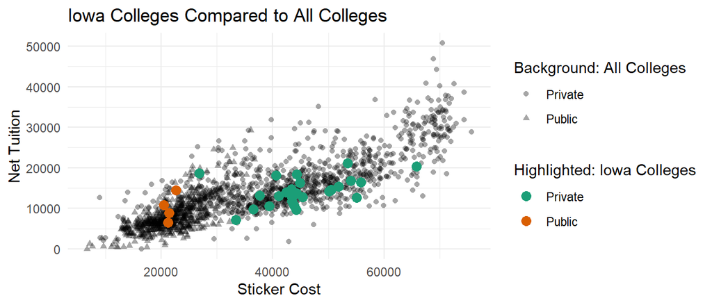

$~$